# Where do the mortality models fail?

Formal event-held-out reef-year residual assessment

# Interpretation

Residuals are calculated from predictions made when the reef-year’s entire bleaching event was excluded from model fitting. A positive residual means the model underestimated mortality; a negative residual means it overestimated mortality. This is intentionally stricter than examining fitted residuals.

For each programme, learner, and held-out event, the 5th and 95th percentile thresholds come only from cross-fitted residuals for the other events. A row is therefore unusual relative to errors the same model made in other bleaching events. Flags identify cases for ecological diagnosis and do **not** remove them from model fitting.

# Event calibration

Event-held-out calibration of the formal BRMS–BRT ensemble

| Programme | Event | n | Unique reefs | ENSO | RONI | SOI | Observed mean | Predicted mean | Observed - predicted | MAE | Underestimated outliers | Overestimated outliers | Severe 2024 misses | Severe 2024 reefs | Low-DHW overpredictions | Low-DHW reefs |
| --- | --- | --- | --- | --- | --- | --- | --- | --- | --- | --- | --- | --- | --- | --- | --- | --- |
| LTMP benthic | 2016 | 22 | 22 | Strong El Nino | 1.75 | -13.3 | 0.183 | 0.168 | 0.016 | 0.145 | 4 | 6 | 0 | 0 | 2 | 2 |
| LTMP benthic | 2017 | 19 | 18 | Neutral | -0.41 | 1.7 | 0.186 | 0.186 | 0.000 | 0.178 | 3 | 4 | 0 | 0 | 0 | 0 |
| LTMP benthic | 2020 | 47 | 47 | Neutral | 0.09 | -2.9 | 0.023 | 0.052 | -0.029 | 0.059 | 1 | 0 | 0 | 0 | 0 | 0 |
| LTMP benthic | 2022 | 36 | 36 | Moderate La Nina | -1.17 | 10.0 | 0.016 | 0.039 | -0.023 | 0.036 | 0 | 0 | 0 | 0 | 0 | 0 |
| LTMP benthic | 2024 | 75 | 65 | Weak El Nino | 0.78 | -2.9 | 0.113 | 0.089 | 0.024 | 0.083 | 5 | 3 | 5 | 5 | 0 | 0 |
| Manta tow | 2016 | 20 | 20 | Strong El Nino | 1.75 | -13.3 | 0.145 | 0.134 | 0.012 | 0.101 | 1 | 2 | 0 | 0 | 1 | 1 |
| Manta tow | 2017 | 23 | 22 | Neutral | -0.41 | 1.7 | 0.131 | 0.110 | 0.021 | 0.098 | 0 | 0 | 0 | 0 | 0 | 0 |
| Manta tow | 2020 | 63 | 63 | Neutral | 0.09 | -2.9 | 0.011 | 0.074 | -0.063 | 0.072 | 0 | 1 | 0 | 0 | 0 | 0 |
| Manta tow | 2022 | 53 | 53 | Moderate La Nina | -1.17 | 10.0 | 0.036 | 0.067 | -0.031 | 0.074 | 1 | 4 | 0 | 0 | 0 | 0 |
| Manta tow | 2024 | 89 | 79 | Weak El Nino | 0.78 | -2.9 | 0.191 | 0.107 | 0.084 | 0.150 | 25 | 6 | 25 | 25 | 0 | 0 |
| MMP inshore | 2017 | 32 | 13 | Neutral | -0.41 | 1.7 | 0.125 | 0.155 | -0.029 | 0.105 | 0 | 8 | 0 | 0 | 0 | 0 |
| MMP inshore | 2022 | 4 | 2 | Moderate La Nina | -1.17 | 10.0 | 0.000 | 0.150 | -0.150 | 0.150 | 0 | 1 | 0 | 0 | 0 | 0 |
| MMP inshore | 2024 | 54 | 18 | Weak El Nino | 0.78 | -2.9 | 0.238 | 0.110 | 0.128 | 0.217 | 21 | 0 | 21 | 10 | 0 | 0 |

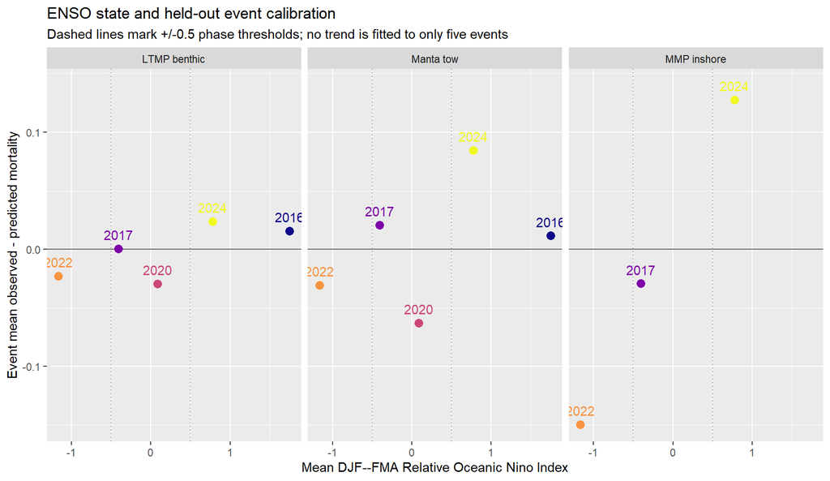

The event sequence does not reduce to one ENSO gradient: 2020 is neutral and 2022 is Moderate La Nina, although both have lower mortality than predicted, while 2024 is Weak El Nino with much higher-than-predicted mortality in manta and MMP. RONI is therefore a candidate context modifier, not a replacement for local rainfall, wind, community composition, or thermal history.

ENSO and GBR-wide ERA5 weather context by event

| Event | ENSO | RONI | SOI | Median coastal Q1 rain | Median max 30d rain | Median reef wind | Median calm fraction |
| --- | --- | --- | --- | --- | --- | --- | --- |
| 2016 | Strong El Nino | 1.75 | -13.30 | 601.71 | 365.26 | 4.92 | 25% |
| 2017 | Neutral | -0.41 | 1.70 | 1003.05 | 521.70 | 4.42 | 27% |
| 2020 | Neutral | 0.09 | -2.90 | 970.23 | 455.06 | 5.63 | 16% |
| 2022 | Moderate La Nina | -1.17 | 9.97 | 802.31 | 409.47 | 5.03 | 20% |
| 2024 | Weak El Nino | 0.78 | -2.90 | 995.15 | 475.61 | 5.61 | 16% |

GBR-wide rainfall is not a monotonic proxy for ENSO in these five events. For example, 2022 is the only Moderate La Nina bleaching summer, but its median Q1 coastal rainfall is lower than in neutral 2017 and 2020 and Weak El Nino 2024. This supports keeping local rainfall and basin-scale ENSO as distinct candidate variables rather than using one to stand in for the other.

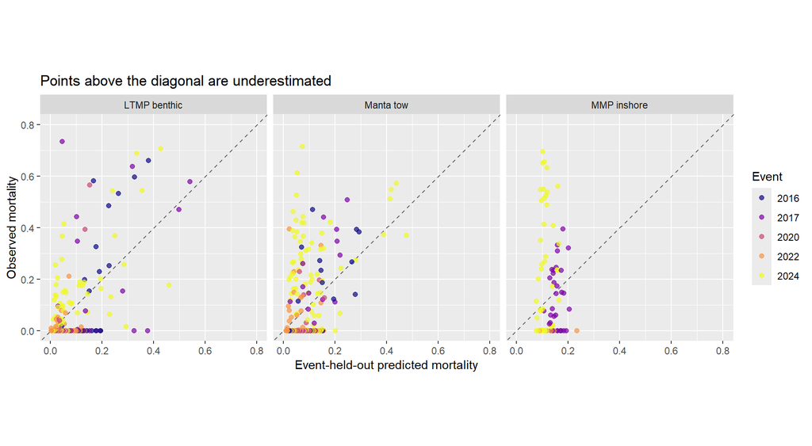

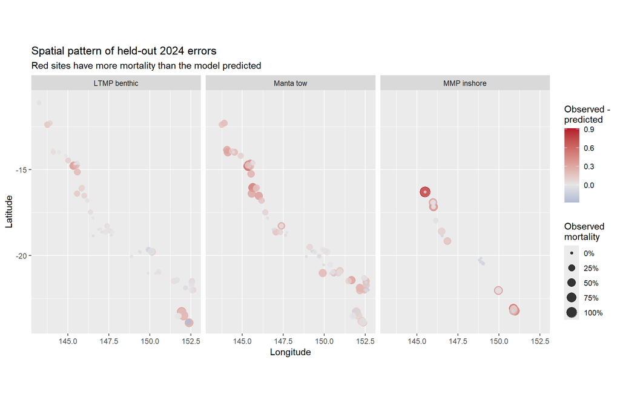

# Does error depend on DHW?

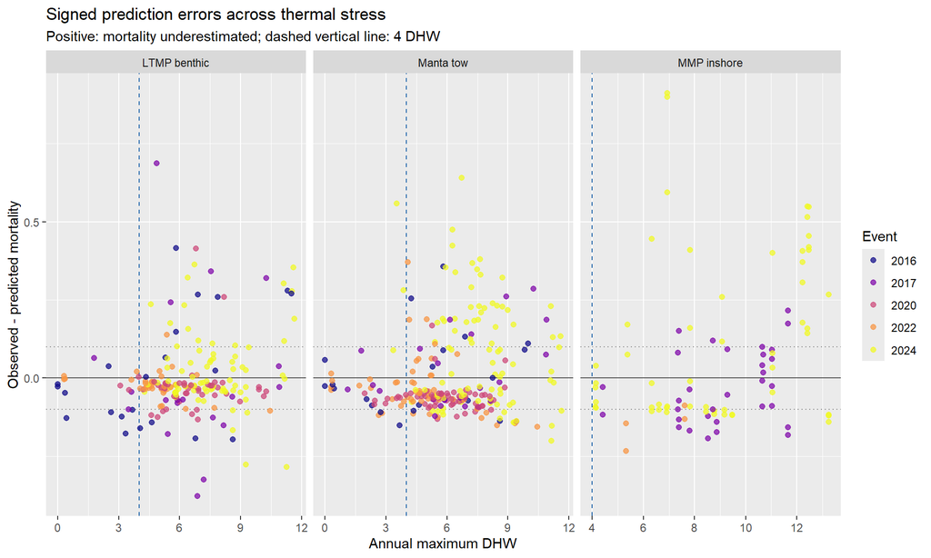

# Priority ecological diagnoses

Two prespecified flags target the concerns motivating this assessment:

- **Severe 2024 miss:** observed mortality at least 20%, underestimated by at least 10 percentage points and beyond the other-event upper residual tail.
- **Low-DHW overprediction:** DHW below 4 and mortality overestimated by at least 10 percentage points and beyond the other-event lower residual tail.

| Flag | Reef-years |
| --- | --- |
| Severe 2024 reef-years | 40 |
| Low-DHW reef-years | 3 |
| All core models underestimate | 39 |
| All core models overestimate | 13 |

Largest severe-mortality underpredictions in 2024

| Programme | Reef | Region | DHW | Observed | Predicted | Observed - predicted | % Acropora before | Freshwater-risk percentile | Partial eReefs <30 PSU | Coastal rain max 30d | ERA5 mean wind | Calm-day fraction | Disturbance | Core-model agreement |
| --- | --- | --- | --- | --- | --- | --- | --- | --- | --- | --- | --- | --- | --- | --- |
| MMP inshore | Snapper Reef (16-006) | Central GBR | 6.9 | 1.000 | 0.089 | 0.911 | 13.8% | 91.6% | FALSE | 908 | 3.16 | 52% | m | all_three_underestimate |
| Manta tow | Linnet Reef (14-126) | Northern GBR | 6.7 | 0.715 | 0.074 | 0.641 | 63.4% | 65.6% | FALSE | 781 | 5.10 | 23% | b | all_three_underestimate |
| Manta tow | Mackay Reef (16-015) | Central GBR | 3.5 | 0.613 | 0.054 | 0.558 | 42.2% | 80.7% | FALSE | 789 | 5.55 | 15% | NA | all_three_underestimate |
| MMP inshore | North Keppel (Ko-no-mie) Island Reef (No 2) (23-004b) | Southern GBR | 12.4 | 0.650 | 0.101 | 0.549 | 97.0% | 89.2% | FALSE | 211 | 7.72 | 0% | b | all_three_underestimate |
| MMP inshore | Humpy (Bur-ye-Bur-ye) Reef (23-016) | Southern GBR | 12.5 | 0.655 | 0.108 | 0.548 | 70.8% | 89.4% | FALSE | 233 | 7.60 | 0% | b | all_three_underestimate |
| Manta tow | Eyrie Reef (14-118) | Northern GBR | 6.3 | 0.526 | 0.051 | 0.475 | 51.5% | 65.3% | FALSE | 781 | 5.60 | 20% | b | all_three_underestimate |
| MMP inshore | Tobias Spit (17-009a) | Central GBR | 6.3 | 0.549 | 0.105 | 0.444 | 27.2% | 93.9% | FALSE | 939 | 2.78 | 62% | m | all_three_underestimate |
| Manta tow | Lizard Island Reef (North West) (14-116a) | Northern GBR | 6.3 | 0.462 | 0.038 | 0.424 | 14.9% | 65.4% | FALSE | 781 | 5.60 | 20% | b | all_three_underestimate |
| MMP inshore | Fitzroy Island Reef (No 1) (16-054a) | Central GBR | 7.8 | 0.524 | 0.114 | 0.410 | 59.0% | 91.8% | FALSE | 1071 | 4.64 | 21% | b | all_three_underestimate |
| MMP inshore | Middle (Ba-la-ba) Island Reef (23-010) | Southern GBR | 12.2 | 0.514 | 0.108 | 0.407 | 76.6% | 89.2% | FALSE | 233 | 7.60 | 0% | b | all_three_underestimate |
| MMP inshore | Barren Island Reef (22-009) | Southern GBR | 11.1 | 0.561 | 0.160 | 0.400 | 84.3% | 52.0% | FALSE | 123 | 7.69 | 1% | b | all_three_underestimate |
| Manta tow | Hastings Reef (16-057) | Central GBR | 7.6 | 0.429 | 0.049 | 0.380 | 18.0% | 87.2% | FALSE | 1033 | 6.12 | 13% | m | all_three_underestimate |
| Manta tow | U/N Reef (21-187) | Southern GBR | 7.2 | 0.442 | 0.075 | 0.367 | 31.4% | 20.4% | FALSE | 155 | 7.63 | 3% | b | all_three_underestimate |
| LTMP benthic | Linnet Reef (14-126) | Northern GBR | 6.7 | 0.414 | 0.052 | 0.362 | 63.4% | 65.6% | FALSE | 781 | 5.10 | 23% | b | all_three_underestimate |
| Manta tow | MacGillivray Reef (14-114) | Northern GBR | 5.9 | 0.389 | 0.035 | 0.354 | 22.2% | 65.4% | FALSE | 781 | 5.60 | 20% | b | all_three_underestimate |
| LTMP benthic | Broomfield Reef (23-048) | Southern GBR | 11.6 | 0.688 | 0.335 | 0.353 | 86.2% | 48.5% | FALSE | 200 | 7.90 | 3% | m | mixed_or_not_outlying |
| Manta tow | Corbett Reef (14-016) | Northern GBR | 7.5 | 0.420 | 0.073 | 0.347 | 29.9% | 20.4% | FALSE | 661 | 5.17 | 18% | b | all_three_underestimate |
| Manta tow | Low Islands Reef (16-028) | Central GBR | 6.4 | 0.418 | 0.079 | 0.338 | 7.4% | 91.9% | FALSE | 992 | 2.83 | 63% | m | all_three_underestimate |
| Manta tow | U/N Reef (13-124) | Northern GBR | 7.7 | 0.384 | 0.053 | 0.331 | 17.7% | 20.4% | FALSE | 776 | 5.20 | 19% | b | all_three_underestimate |
| LTMP benthic | Martin Reef (14-123) | Northern GBR | 6.4 | 0.368 | 0.046 | 0.322 | 58.4% | 65.6% | FALSE | 781 | 5.10 | 23% | b | mixed_or_not_outlying |
| Manta tow | Myrmidon Reef (18-034) | Central GBR | 8.7 | 0.364 | 0.044 | 0.321 | 15.6% | 79.4% | FALSE | 611 | 6.50 | 4% | b | all_three_underestimate |
| LTMP benthic | Lady Musgrave Reef (23-082a) | Southern GBR | 11.1 | 0.543 | 0.241 | 0.302 | 94.7% | 62.3% | FALSE | 330 | 7.67 | 1% | m | mixed_or_not_outlying |
| Manta tow | U/N Reef (21-529) | Southern GBR | 7.2 | 0.367 | 0.077 | 0.290 | 38.6% | 20.4% | FALSE | 155 | 7.63 | 4% | b | all_three_underestimate |
| Manta tow | Swinger Reef (15-030) | Northern GBR | 3.9 | 0.346 | 0.066 | 0.280 | 16.5% | 70.4% | FALSE | 841 | 5.37 | 15% | b | all_three_underestimate |
| LTMP benthic | One Tree Island Reef (23-055a) | Southern GBR | 11.5 | 0.706 | 0.427 | 0.278 | 91.7% | 52.0% | FALSE | 246 | 7.84 | 2% | m | mixed_or_not_outlying |
| MMP inshore | Pelican Island Reef (23-017) | Southern GBR | 13.3 | 0.408 | 0.142 | 0.266 | 13.4% | 94.8% | FALSE | 233 | 5.65 | 10% | b | all_three_underestimate |
| MMP inshore | Magnetic Island Reef (No 2) (19-009c) | Central GBR | 9.1 | 0.350 | 0.092 | 0.258 | 18.3% | 96.7% | FALSE | 443 | 2.83 | 60% | b | all_three_underestimate |
| Manta tow | Penrith Reef (21-025) | Southern GBR | 8.2 | 0.421 | 0.182 | 0.239 | 2.5% | 71.6% | FALSE | 223 | 7.60 | 1% | NA | all_three_underestimate |
| Manta tow | U/N Reef (22-084) | Southern GBR | 8.5 | 0.297 | 0.066 | 0.231 | 10.1% | 20.4% | FALSE | 198 | 7.66 | 5% | NA | all_three_underestimate |
| Manta tow | Lady Musgrave Reef (23-082a) | Southern GBR | 11.1 | 0.378 | 0.148 | 0.230 | 94.7% | 62.3% | FALSE | 330 | 7.67 | 1% | m | all_three_underestimate |

Environmental context of severe 2024 misses by region

| programme | region_block | Reef-years | Observed | Predicted | DHW | Pre-event Acropora | Coastal rain max 30d | Mean wind |
| --- | --- | --- | --- | --- | --- | --- | --- | --- |
| LTMP benthic | Northern GBR | 2 | 0.391 | 0.049 | 6.565 | 0.609 | 781 | 5.10 |
| LTMP benthic | Southern GBR | 3 | 0.646 | 0.334 | 11.417 | 0.909 | 259 | 7.81 |
| MMP inshore | Central GBR | 5 | 0.552 | 0.113 | 7.102 | 0.420 | 772 | 3.68 |
| MMP inshore | Southern GBR | 5 | 0.558 | 0.124 | 12.286 | 0.684 | 207 | 7.25 |
| Manta tow | Central GBR | 5 | 0.417 | 0.060 | 6.416 | 0.219 | 774 | 5.44 |
| Manta tow | Northern GBR | 10 | 0.399 | 0.050 | 6.652 | 0.315 | 760 | 5.44 |
| Manta tow | Southern GBR | 10 | 0.341 | 0.099 | 8.191 | 0.300 | 192 | 7.65 |

These summaries separate two candidate failure modes without treating either as proven causation: northern and central misses coincide with high coastal rainfall, whereas southern misses combine higher DHW with high pre-event Acropora composition. Both mechanisms should therefore be tested in the next blocked refit rather than represented by a single steeper DHW curve.

Largest overpredictions below 4 DHW

| Programme | Event | Reef | Region | DHW | Observed | Predicted | Observed - predicted | % Acropora before | Coastal rain max 30d | ERA5 mean wind | Calm-day fraction | Disturbance | Core-model agreement |
| --- | --- | --- | --- | --- | --- | --- | --- | --- | --- | --- | --- | --- | --- |
| LTMP benthic | 2016 | Havannah Reef (18-065) | Central GBR | 3.3 | 0 | 0.177 | -0.177 | 26.3% | 392 | 4.27 | 18% | b | mixed_or_not_outlying |
| Manta tow | 2016 | Green Island Reef (16-049) | Central GBR | 3.7 | 0 | 0.151 | -0.151 | 1.9% | 414 | 5.16 | 16% | NA | mixed_or_not_outlying |
| LTMP benthic | 2016 | Lady Musgrave Reef (23-082a) | Southern GBR | 0.4 | 0 | 0.128 | -0.128 | 91.5% | 194 | 7.43 | 0% | NA | mixed_or_not_outlying |

The strict large-error rule identifies few individual low-DHW reefs, but the event-calibration table shows a broader smaller bias: the ensemble overpredicts mean mortality in the low-mortality 2020 and 2022 events for LTMP and manta, and in the very small 2022 MMP sample. This supports testing a sharper occurrence boundary or lower background component, while keeping that task separate from the missing severe-2024 mechanism.

The December–March SOI separates the La Nina-like 2022 event from neutral 2020, so it cannot by itself explain why both events had lower mortality than predicted. It remains a useful atmospheric cross-check because SOI reflects the circulation relevant to Australian rainfall. In 2024, mean summer RONI is El Nino while mean SOI is neutral/mixed, so oceanic and atmospheric indicators should not be treated as interchangeable.

# Complete hand-off table

The machine-readable file `output/prediction_outliers/priority_reef_years.csv` contains the full context, including descriptions, pre-event cover, Acropora composition, individual BRMS and BRT residuals, and model-consensus flags. It is the appropriate table for adding hypothesised ecological mechanisms such as freshwater exposure, community susceptibility, unrecorded disturbance, or unusual prior exposure. The companion `priority_observation_rows.csv` retains every contributing survey row; `priority_reef_years.csv` selects the largest absolute error within each programme–reef–event and records its number of flagged observations.

# Beta versus binomial response family

The binomial comparison uses 100 pseudo-trials solely to put the estimated proportions on a common binomial scale. An observation-level random effect absorbs extra-binomial variation. It is therefore a response-family sensitivity, not a claim that every survey observed exactly 100 independent colonies.

Binomial folds that fail the prespecified diagnostic gate

| Programme | Event | Maximum R-hat | Minimum bulk ESS | Minimum tail ESS | Divergences | Tree-depth hits |
| --- | --- | --- | --- | --- | --- | --- |
| manta | 2022 | 1.013 | 462.951 | 1054.571 | 0 | 0 |

```
The binomial sensitivity is not eligible for model promotion because at least one held-out fold remains diagnostically unresolved.
```

Overall event-held-out response-family comparison

| Programme | Family | n | MAE | RMSE | Predictive R2 | Mean observed - predicted | Severe-loss MAE | Low-DHW observed - predicted |
| --- | --- | --- | --- | --- | --- | --- | --- | --- |
| LTMP benthic | Binomial-OLRE sensitivity | 199 | 0.116 | 0.167 | 0.000 | -0.064 | 0.216 | -0.069 |
| LTMP benthic | Primary beta-family BRMS | 199 | 0.089 | 0.133 | 0.360 | -0.010 | 0.220 | -0.057 |
| Manta tow | Binomial-OLRE sensitivity | 248 | 0.137 | 0.176 | -0.303 | -0.055 | 0.215 | -0.079 |
| Manta tow | Primary beta-family BRMS | 248 | 0.105 | 0.141 | 0.169 | 0.011 | 0.221 | -0.019 |
| MMP inshore | Binomial-OLRE sensitivity | 90 | 0.223 | 0.281 | -0.472 | -0.026 | 0.286 | NaN |
| MMP inshore | Primary beta-family BRMS | 90 | 0.174 | 0.243 | -0.098 | 0.053 | 0.288 | NaN |

Like-for-like event-held-out family sensitivity

| Programme | Family | Event | Observed mean | Predicted mean | Observed - predicted | MAE | RMSE | Severe-loss MAE | Low-DHW observed - predicted |
| --- | --- | --- | --- | --- | --- | --- | --- | --- | --- |
| LTMP benthic | Primary beta-family BRMS | 2016 | 0.183 | 0.189 | -0.006 | 0.152 | 0.185 | 0.199 | -0.098 |
| LTMP benthic | Primary beta-family BRMS | 2017 | 0.186 | 0.186 | 0.000 | 0.176 | 0.237 | 0.269 | -0.057 |
| LTMP benthic | Primary beta-family BRMS | 2020 | 0.023 | 0.059 | -0.036 | 0.065 | 0.097 | 0.339 | -0.033 |
| LTMP benthic | Primary beta-family BRMS | 2022 | 0.016 | 0.046 | -0.030 | 0.041 | 0.054 | 0.125 | 0.001 |
| LTMP benthic | Primary beta-family BRMS | 2024 | 0.113 | 0.101 | 0.012 | 0.085 | 0.125 | 0.198 | NA |
| LTMP benthic | Binomial-OLRE sensitivity | 2016 | 0.183 | 0.212 | -0.028 | 0.146 | 0.178 | 0.187 | -0.072 |
| LTMP benthic | Binomial-OLRE sensitivity | 2017 | 0.186 | 0.331 | -0.145 | 0.255 | 0.318 | 0.277 | -0.077 |
| LTMP benthic | Binomial-OLRE sensitivity | 2020 | 0.023 | 0.053 | -0.031 | 0.065 | 0.119 | 0.408 | -0.026 |
| LTMP benthic | Binomial-OLRE sensitivity | 2022 | 0.016 | 0.096 | -0.080 | 0.085 | 0.096 | 0.090 | -0.086 |
| LTMP benthic | Binomial-OLRE sensitivity | 2024 | 0.113 | 0.180 | -0.067 | 0.117 | 0.161 | 0.185 | NA |
| Manta tow | Primary beta-family BRMS | 2016 | 0.145 | 0.134 | 0.012 | 0.101 | 0.129 | 0.148 | -0.055 |
| Manta tow | Primary beta-family BRMS | 2017 | 0.131 | 0.110 | 0.021 | 0.098 | 0.120 | 0.189 | -0.004 |
| Manta tow | Primary beta-family BRMS | 2020 | 0.011 | 0.074 | -0.063 | 0.072 | 0.076 | 0.167 | -0.066 |
| Manta tow | Primary beta-family BRMS | 2022 | 0.036 | 0.067 | -0.031 | 0.074 | 0.097 | 0.249 | -0.044 |
| Manta tow | Primary beta-family BRMS | 2024 | 0.191 | 0.107 | 0.084 | 0.150 | 0.195 | 0.238 | 0.309 |
| Manta tow | Binomial-OLRE sensitivity | 2016 | 0.145 | 0.257 | -0.111 | 0.154 | 0.177 | 0.145 | -0.130 |
| Manta tow | Binomial-OLRE sensitivity | 2017 | 0.131 | 0.255 | -0.124 | 0.153 | 0.190 | 0.189 | -0.025 |
| Manta tow | Binomial-OLRE sensitivity | 2020 | 0.011 | 0.124 | -0.112 | 0.118 | 0.142 | 0.107 | -0.156 |
| Manta tow | Binomial-OLRE sensitivity | 2022 | 0.036 | 0.104 | -0.068 | 0.104 | 0.132 | 0.208 | -0.095 |
| Manta tow | Binomial-OLRE sensitivity | 2024 | 0.191 | 0.168 | 0.023 | 0.163 | 0.213 | 0.234 | 0.290 |
| MMP inshore | Primary beta-family BRMS | 2017 | 0.125 | 0.155 | -0.029 | 0.105 | 0.119 | 0.116 | NA |
| MMP inshore | Primary beta-family BRMS | 2022 | 0.000 | 0.150 | -0.150 | 0.150 | 0.159 | NA | NA |
| MMP inshore | Primary beta-family BRMS | 2024 | 0.238 | 0.121 | 0.116 | 0.217 | 0.297 | 0.357 | NA |
| MMP inshore | Binomial-OLRE sensitivity | 2017 | 0.125 | 0.357 | -0.231 | 0.231 | 0.261 | 0.108 | NA |
| MMP inshore | Binomial-OLRE sensitivity | 2022 | 0.000 | 0.207 | -0.207 | 0.207 | 0.212 | NA | NA |
| MMP inshore | Binomial-OLRE sensitivity | 2024 | 0.238 | 0.128 | 0.110 | 0.219 | 0.297 | 0.358 | NA |

Direct comparison for the held-out 2024 event

| Programme | Family | Observed 2024 | Predicted 2024 | Observed - predicted | RMSE |
| --- | --- | --- | --- | --- | --- |
| LTMP benthic | Primary beta-family BRMS | 0.113 | 0.101 | 0.012 | 0.125 |
| LTMP benthic | Binomial-OLRE sensitivity | 0.113 | 0.180 | -0.067 | 0.161 |
| Manta tow | Primary beta-family BRMS | 0.191 | 0.107 | 0.084 | 0.195 |
| Manta tow | Binomial-OLRE sensitivity | 0.191 | 0.168 | 0.023 | 0.213 |
| MMP inshore | Primary beta-family BRMS | 0.238 | 0.121 | 0.116 | 0.297 |
| MMP inshore | Binomial-OLRE sensitivity | 0.238 | 0.128 | 0.110 | 0.297 |

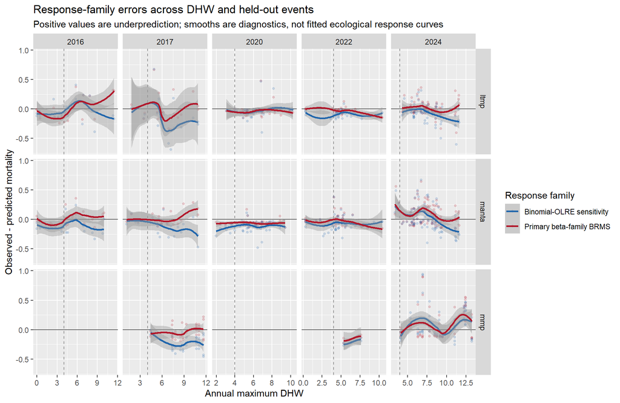

Because the response is loss relative to estimated pre-event coral cover, not a count of independent dead colonies, the binomial model cannot use a literal survey denominator. Its 100 pseudo-trials and observation-level random effect make this a useful shape sensitivity only. Model promotion still depends on held-out predictive performance and clean sampling diagnostics. The current manta-2022 fold has no divergences or tree-depth hits, but its reef-level standard-deviation parameter remains above the R-hat gate after stricter sampling; binomial results are therefore interpreted but not promoted.